## Method

### Design of experiment

I need to do more research here.. What is DOE, How it was done

Should this be part of Method or separate.

formula used by OEM for efficiency calcultions. Not sure if they modeled the data (what model).

### Preparation (maybe include in design of experiment?)

Grinding Screens `321-SC-013` and `321-SC-014` were chosen for the comparison test. Ten `0.25 MTQ` panels were installed in `321-SC-014` on the $30^{th}$ of September.

`321-SC-013` was also fitted with relatively new `0.23 MT` screen panels. The oldest panels were installed 9th September.

### Sampling

Survey 1 was conducted while `Mill 2` was offline due to an issue with the mill liners. Survey 2 conducted with two secondary mills online but with higher than usual recirculating load. During the surveys, feed to the mills and recirculating load were steady for at least an hour.

Five (`5`) personnel were involved in obtaining the survey samples during each survey:

- One person took samples at the Primary Distributor, `DI-028`, that feeds the seven screen sets.
- Four personnel took overflow cuts from the individual screen decks’ lips using deep and wide rimmed plastic containers. care was given to cut streams entirely at constant speeds while ensuring no container overflow or spillage. Samples were simultaneously taken from both sides of individual screen decks by two personnel and then individual deck’s samples were combined.

Two sample cuts were taken from the feeds of `321-SC-013` and `321-SC-014`, as well as from the individual deck lip overflows.

Screen cluster feed and individual deck overflow samples were weighed, wet screened to get $-38 µm$ fractions, dried in the oven and sieved to determine the weight of each size fraction.

The following screens sizes were used ($\mu M$)

```
## sieves_used
##    0   38   53   75  106  150  180  212  300  425  600 1180
##    1    1    1    1    1    1    1    1    1    1    1    1
```

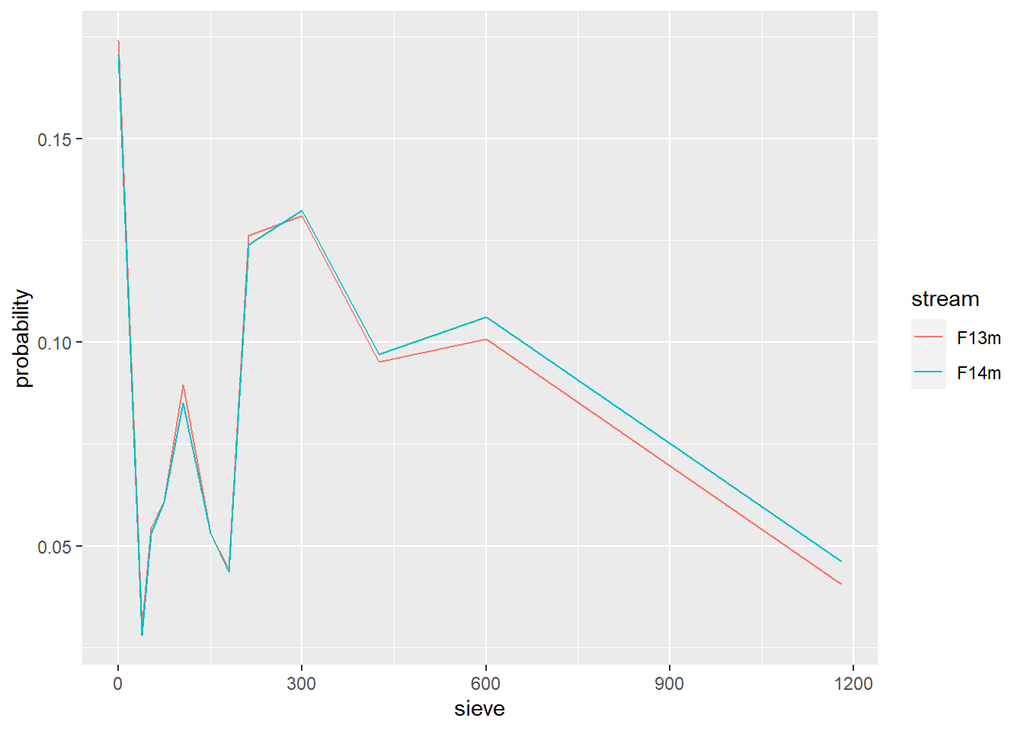

Each stream sample’s cummulative mass distribution function was modelled with two commonly used models in practise represent a vast variety of communution circuit products very well, namely the:

**Rosin-Rammler distribution** and  
**Gauss-Gaudin-Schumann distribution**.

The model that best fit each stream was selected with the aid of statistics. The modeled distribution functions ennabled more accurate interpolation of cumulative mass percentages.